```python
%matplotlib notebook
import matplotlib.pyplot as plt
import numpy as np
import pymc3 as pm
import arviz as az
import scipy.stats as stats
from scipy.special import logsumexp
import pandas as pd
import theano
import os
```

# Load Data

```python
data = pd.read_csv(os.path.join('data', 'Wines2012.csv'), delimiter=';')
data.head()
```

|  | judge | flight | wine | score | wine.amer | judge.amer |
| --- | --- | --- | --- | --- | --- | --- |
| 0 | Jean-M Cardebat | white | A1 | 10.0 | 1 | 0 |
| 1 | Jean-M Cardebat | white | B1 | 13.0 | 1 | 0 |
| 2 | Jean-M Cardebat | white | C1 | 14.0 | 0 | 0 |
| 3 | Jean-M Cardebat | white | D1 | 15.0 | 0 | 0 |
| 4 | Jean-M Cardebat | white | E1 | 8.0 | 1 | 0 |

# 1

```python
# Standardize variables
data['score_std'] = data['score'] / data['score'].max()
```

```python
data['judge'].value_counts()
```

```
Olivier Gergaud    20
Linda Murphy       20
Jean-M Cardebat    20
Daniele Meulder    20
John Foy           20
Tyler Colman       20
Francis Schott     20
Robert Hodgson     20
Jamal Rayyis       20
Name: judge, dtype: int64
```

```python
data['wine'].value_counts()
```

```
C2    9
F1    9
J1    9
B1    9
D1    9
I1    9
G2    9
I2    9
B2    9
D2    9
E2    9
A1    9
H2    9
A2    9
E1    9
C1    9
H1    9
F2    9
G1    9
J2    9
Name: wine, dtype: int64
```

```python
# There are 20 wines and 9 judges
num_wines = data['wine'].unique().shape[0]
num_judges = data['judge'].unique().shape[0]
print('There are {:d} wines and {:d} judges'.format(num_wines, num_judges))
```

```
There are 20 wines and 9 judges
```

## Make numerical IDs for judges and wines

```python
judge_to_idx = {judge: idx for idx, judge in enumerate(data['judge'].unique())}
idx_to_judge = {judge_to_idx[judge]: judge for judge in judge_to_idx}
```

```python
wine_to_idx = {wine: idx for idx, wine in enumerate(data['wine'].unique())}
idx_to_wine = {wine_to_idx[wine]: wine for wine in wine_to_idx}
```

```python
data['judge_idx'] = data['judge'].apply(lambda x: judge_to_idx[x])
data['wine_idx'] = data['wine'].apply(lambda x: wine_to_idx[x])
```

```python
data['judge_idx'].value_counts()
```

```
8    20
7    20
6    20
5    20
4    20
3    20
2    20
1    20
0    20
Name: judge_idx, dtype: int64
```

```python
data['wine_idx'].value_counts()
```

```
19    9
18    9
1     9
2     9
3     9
4     9
5     9
6     9
7     9
8     9
9     9
10    9
11    9
12    9
13    9
14    9
15    9
16    9
17    9
0     9
Name: wine_idx, dtype: int64
```

## Define the Model

```python
with pm.Model() as model_1_1:

    aW = pm.Normal('aW', mu=0.5, sigma=0.25, shape=num_wines)
    aJ = pm.Normal('aJ', mu=0.0, sigma=0.25, shape=num_judges) # Judge bias is centered around zero

    mu = pm.Deterministic('mu', aW[data['wine_idx']] + aJ[data['judge_idx']])
    sigma = pm.Exponential('sigma', lam=1)

    score = pm.Normal('score', mu=mu, sigma=sigma, observed=data['score_std'])

    trace_1_1 = pm.sample(1000, tune=1000)
```

[output not shown]

Note the warning about the effective sample size. This can also be seen in the summary of the model. The columns starting with ess_ are estimates of the effective sample size:

```python
pm.summary(trace_1_1, var_names=['~mu'])
```

|  | mean | sd | hpd_3% | hpd_97% | mcse_mean | mcse_sd | ess_mean | ess_sd | ess_bulk | ess_tail | r_hat |
| --- | --- | --- | --- | --- | --- | --- | --- | --- | --- | --- | --- |
| aW[0] | 0.584 | 0.063 | 0.472 | 0.707 | 0.006 | 0.004 | 124.0 | 124.0 | 125.0 | 369.0 | 1.01 |
| aW[1] | 0.606 | 0.065 | 0.484 | 0.725 | 0.006 | 0.004 | 137.0 | 137.0 | 137.0 | 419.0 | 1.01 |
| aW[2] | 0.546 | 0.064 | 0.423 | 0.662 | 0.006 | 0.004 | 123.0 | 123.0 | 123.0 | 377.0 | 1.01 |
| aW[3] | 0.608 | 0.064 | 0.491 | 0.723 | 0.006 | 0.004 | 128.0 | 128.0 | 128.0 | 367.0 | 1.01 |
| aW[4] | 0.578 | 0.064 | 0.454 | 0.694 | 0.006 | 0.004 | 119.0 | 119.0 | 120.0 | 416.0 | 1.01 |
| aW[5] | 0.564 | 0.064 | 0.442 | 0.677 | 0.005 | 0.004 | 135.0 | 135.0 | 134.0 | 414.0 | 1.01 |
| aW[6] | 0.548 | 0.064 | 0.438 | 0.666 | 0.006 | 0.004 | 133.0 | 133.0 | 133.0 | 441.0 | 1.01 |
| aW[7] | 0.533 | 0.063 | 0.420 | 0.650 | 0.006 | 0.004 | 122.0 | 122.0 | 123.0 | 417.0 | 1.01 |
| aW[8] | 0.544 | 0.064 | 0.429 | 0.662 | 0.006 | 0.004 | 126.0 | 126.0 | 126.0 | 364.0 | 1.01 |
| aW[9] | 0.541 | 0.062 | 0.422 | 0.656 | 0.005 | 0.004 | 137.0 | 137.0 | 139.0 | 415.0 | 1.01 |
| aW[10] | 0.580 | 0.065 | 0.446 | 0.687 | 0.006 | 0.004 | 130.0 | 130.0 | 130.0 | 511.0 | 1.01 |
| aW[11] | 0.647 | 0.063 | 0.528 | 0.758 | 0.005 | 0.004 | 141.0 | 141.0 | 143.0 | 484.0 | 1.01 |
| aW[12] | 0.510 | 0.062 | 0.396 | 0.622 | 0.006 | 0.004 | 118.0 | 118.0 | 118.0 | 387.0 | 1.01 |
| aW[13] | 0.605 | 0.063 | 0.490 | 0.719 | 0.006 | 0.004 | 116.0 | 116.0 | 117.0 | 312.0 | 1.01 |
| aW[14] | 0.583 | 0.063 | 0.469 | 0.704 | 0.006 | 0.004 | 122.0 | 122.0 | 122.0 | 275.0 | 1.01 |
| aW[15] | 0.561 | 0.063 | 0.438 | 0.669 | 0.006 | 0.004 | 127.0 | 127.0 | 128.0 | 360.0 | 1.01 |
| aW[16] | 0.566 | 0.062 | 0.447 | 0.679 | 0.005 | 0.004 | 139.0 | 139.0 | 140.0 | 404.0 | 1.01 |
| aW[17] | 0.536 | 0.062 | 0.425 | 0.655 | 0.005 | 0.004 | 133.0 | 133.0 | 134.0 | 350.0 | 1.01 |
| aW[18] | 0.437 | 0.063 | 0.317 | 0.548 | 0.005 | 0.004 | 134.0 | 134.0 | 136.0 | 438.0 | 1.01 |
| aW[19] | 0.621 | 0.064 | 0.503 | 0.736 | 0.006 | 0.004 | 121.0 | 121.0 | 121.0 | 376.0 | 1.01 |
| aJ[0] | 0.078 | 0.057 | -0.015 | 0.196 | 0.006 | 0.004 | 101.0 | 101.0 | 102.0 | 315.0 | 1.01 |
| aJ[1] | 0.109 | 0.057 | 0.001 | 0.211 | 0.006 | 0.004 | 101.0 | 96.0 | 101.0 | 331.0 | 1.01 |
| aJ[2] | 0.285 | 0.057 | 0.187 | 0.393 | 0.006 | 0.004 | 103.0 | 100.0 | 104.0 | 278.0 | 1.01 |
| aJ[3] | 0.182 | 0.057 | 0.082 | 0.288 | 0.006 | 0.004 | 107.0 | 107.0 | 107.0 | 330.0 | 1.01 |
| aJ[4] | 0.060 | 0.057 | -0.048 | 0.158 | 0.005 | 0.004 | 108.0 | 108.0 | 108.0 | 290.0 | 1.01 |
| aJ[5] | 0.234 | 0.057 | 0.137 | 0.343 | 0.006 | 0.004 | 106.0 | 104.0 | 107.0 | 253.0 | 1.01 |
| aJ[6] | 0.119 | 0.056 | 0.013 | 0.221 | 0.006 | 0.004 | 104.0 | 102.0 | 105.0 | 359.0 | 1.01 |
| aJ[7] | 0.193 | 0.056 | 0.092 | 0.297 | 0.006 | 0.004 | 102.0 | 98.0 | 102.0 | 359.0 | 1.01 |
| aJ[8] | 0.195 | 0.056 | 0.099 | 0.302 | 0.006 | 0.004 | 104.0 | 103.0 | 105.0 | 321.0 | 1.01 |
| sigma | 0.117 | 0.007 | 0.105 | 0.129 | 0.000 | 0.000 | 1162.0 | 1162.0 | 1159.0 | 1302.0 | 1.00 |

I can get around this issue by scaling the scores in a different way. Maybe the issue is that the scores are not normally distributed when they are scaled by dividing by the maximum.

```python
data['score_std_2'] = ( data['score'] - data['score'].mean() ) / data['score'].std()
```

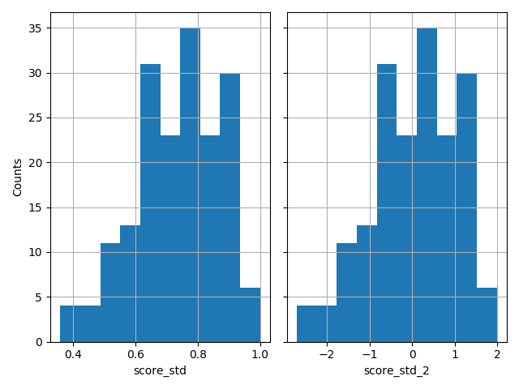

```python
fig, axes = plt.subplots(1,2,sharey=True)
fig.set_tight_layout(True)

data['score_std'].hist(ax=axes[0])
data['score_std_2'].hist(ax=axes[1])

axes[0].set_xlabel('score_std')
axes[1].set_xlabel('score_std_2')
axes[0].set_ylabel('Counts')
```

```python
with pm.Model() as model_1_2:

    aW = pm.Normal('aW', mu=0.0, sigma=0.5, shape=num_wines)
    aJ = pm.Normal('aJ', mu=0.0, sigma=0.5, shape=num_judges)

    mu = pm.Deterministic('mu', aW[data['wine_idx']] + aJ[data['judge_idx']])
    sigma = pm.Exponential('sigma', lam=1)

    score = pm.Normal('score', mu=mu, sigma=sigma, observed=data['score_std_2'])

    trace_1_2 = pm.sample(1000, tune=1000)
```

```python
pm.summary(trace_1_2)
```

|  | mean | sd | hpd_3% | hpd_97% | mcse_mean | mcse_sd | ess_mean | ess_sd | ess_bulk | ess_tail | r_hat |
| --- | --- | --- | --- | --- | --- | --- | --- | --- | --- | --- | --- |
| aW[0] | 0.119 | 0.259 | -0.364 | 0.611 | 0.005 | 0.005 | 2819.0 | 1160.0 | 2825.0 | 1667.0 | 1.00 |
| aW[1] | 0.233 | 0.256 | -0.237 | 0.708 | 0.005 | 0.004 | 3062.0 | 1646.0 | 3070.0 | 1525.0 | 1.00 |
| aW[2] | -0.101 | 0.251 | -0.577 | 0.352 | 0.005 | 0.006 | 2744.0 | 853.0 | 2727.0 | 1437.0 | 1.00 |
| aW[3] | 0.240 | 0.264 | -0.244 | 0.741 | 0.005 | 0.006 | 2947.0 | 1118.0 | 2943.0 | 1293.0 | 1.01 |
| aW[4] | 0.073 | 0.259 | -0.445 | 0.540 | 0.005 | 0.006 | 2853.0 | 931.0 | 2836.0 | 1471.0 | 1.00 |
| ... | ... | ... | ... | ... | ... | ... | ... | ... | ... | ... | ... |
| mu[176] | 0.223 | 0.295 | -0.368 | 0.741 | 0.004 | 0.005 | 5657.0 | 1625.0 | 5656.0 | 1655.0 | 1.00 |
| mu[177] | 0.041 | 0.299 | -0.554 | 0.584 | 0.004 | 0.007 | 5053.0 | 917.0 | 5105.0 | 1471.0 | 1.00 |
| mu[178] | -0.510 | 0.303 | -1.095 | 0.037 | 0.005 | 0.004 | 3761.0 | 2499.0 | 3800.0 | 1535.0 | 1.00 |
| mu[179] | 0.529 | 0.300 | -0.055 | 1.096 | 0.005 | 0.004 | 4330.0 | 2708.0 | 4320.0 | 1589.0 | 1.00 |
| sigma | 0.847 | 0.049 | 0.762 | 0.941 | 0.001 | 0.001 | 3419.0 | 3419.0 | 3373.0 | 1593.0 | 1.00 |

210 rows × 11 columns

## Prior Samples

```python
with model_1_2:
    prior_samples = pm.sample_prior_predictive(var_names=['aW', 'aJ', 'mu'])
```

```python
prior_samples['aJ'].shape
```

```
(500, 9)
```

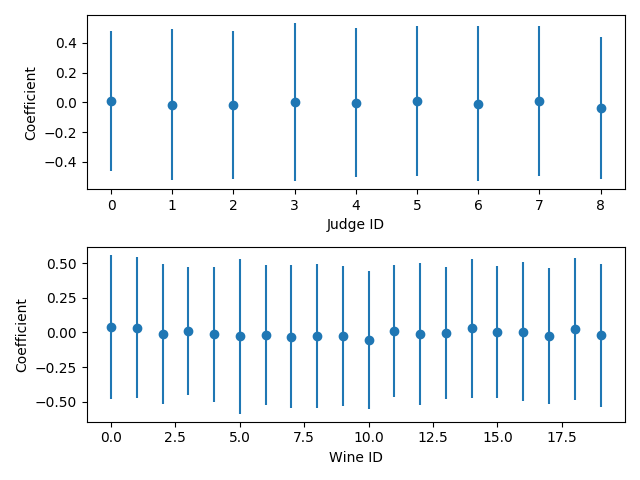

```python
fig, axes = plt.subplots(2,1)
fig.set_tight_layout(True)

axes[0].errorbar(range(num_judges), prior_samples['aJ'].mean(axis=0), yerr=prior_samples['aJ'].std(axis=0),
                 ls='none',marker='o')
axes[0].set_xlabel('Judge ID')
axes[0].set_ylabel('Coefficient')

axes[1].errorbar(range(num_wines), prior_samples['aW'].mean(axis=0), yerr=prior_samples['aW'].std(axis=0),
                 ls='none',marker='o')
axes[1].set_xlabel('Wine ID')
axes[1].set_ylabel('Coefficient')
```

```python
prior_samples['mu'].shape
```

```
(500, 180)
```

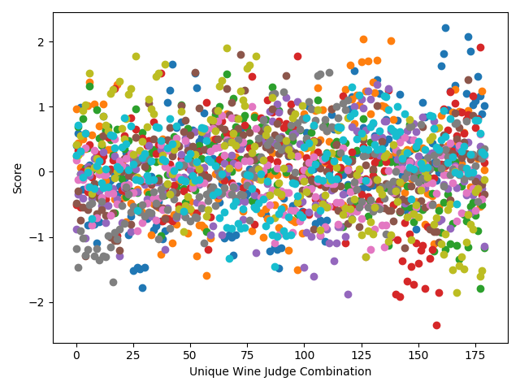

```python
fig, ax = plt.subplots(1,1)
fig.set_tight_layout(True)

num_samples = prior_samples['aW'].shape[0]
wines_ = np.array(range(num_wines))
judges_ = np.array(range(num_judges))
mu_ = np.zeros((num_samples, num_wines*num_judges))

for i_w in range(num_wines):
    for i_j in range(num_judges):
        # mu_[:,i_w*num_judges + i_j] = prior_samples['aW'][:,i_w] + prior_samples['aJ'][:,i_j]
        mu_[:,i_w + i_j*num_wines] = prior_samples['aW'][:,i_w] + prior_samples['aJ'][:,i_j]

for i in range(10):
    ax.scatter(range(num_judges * num_wines), mu_[i,:], c='C{:d}'.format(i%10))

ax.set_xlabel('Unique Wine Judge Combination')
ax.set_ylabel('Score')
```

```python
# test that pymc3 gives the same result
np.sum(prior_samples['mu'] - mu_)
```

```
-4.796163466380676e-14
```

## Look at Trace

I need to set compact=True, because the parameters have such a high dimension

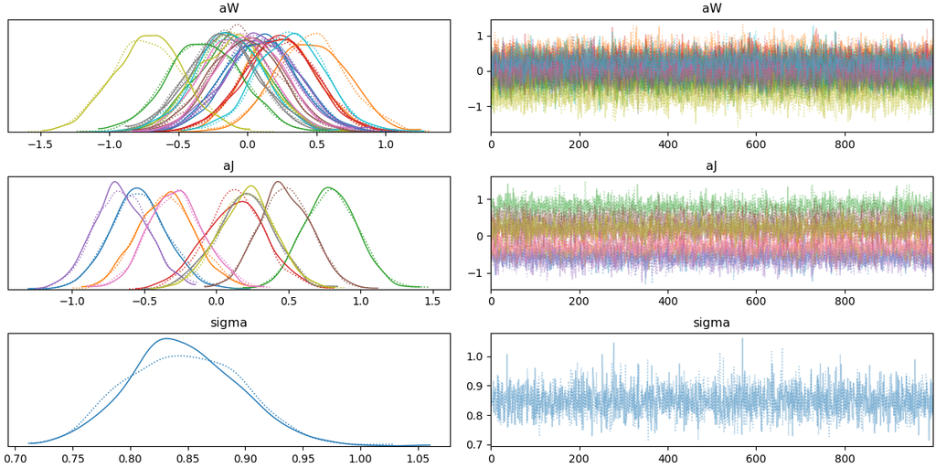

```
array([[<matplotlib.axes._subplots.AxesSubplot object at 0x7ff8e8ccd9d0>,
      dtype=object)
```

```python
az.plot_trace(trace_1_2, var_names=['~mu'], compact=True)
```

## Predictions

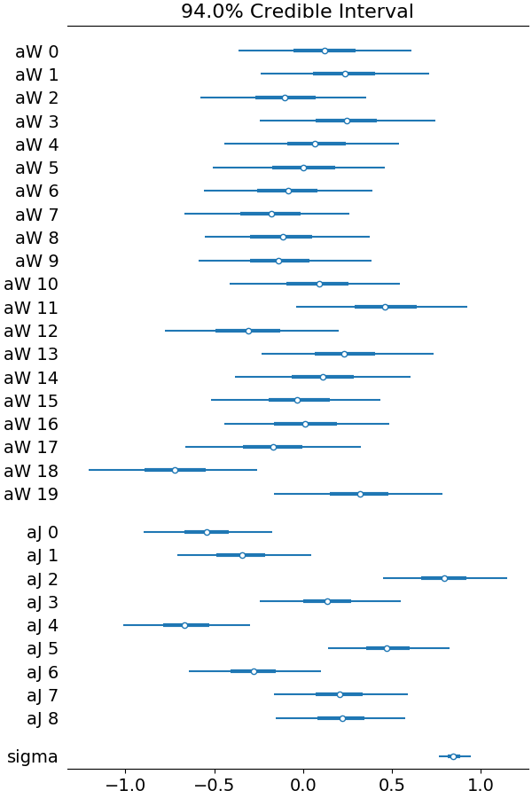

```
array([<matplotlib.axes._subplots.AxesSubplot object at 0x7ff8f09336d0>],
      dtype=object)
```

```python
az.plot_forest(trace_1_2, var_names=['~mu'],combined=True)
```

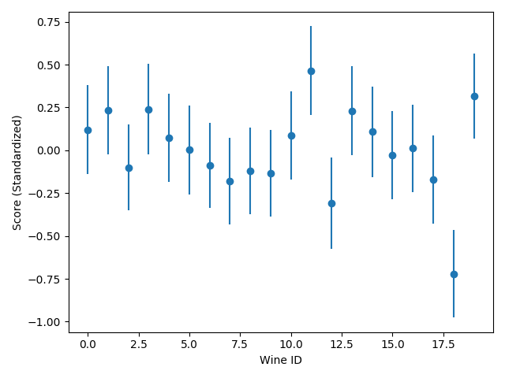

```python
# Wines only (completely unbiased Judge)
fig, ax = plt.subplots(1,1)
fig.set_tight_layout(True)

ax.errorbar(range(num_wines), trace_1_2['aW'].mean(axis=0), yerr=trace_1_2['aW'].std(axis=0),
            ls='none', marker='o')
ax.set_xlabel('Wine ID')
ax.set_ylabel('Score (Standardized)')
```

The curve above will be shifted byt the Judge bias aJ, but the shape will no change in this model.

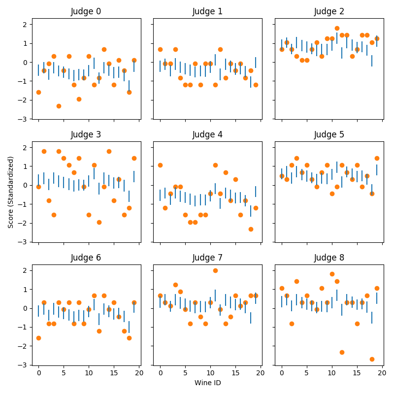

```python
# Wine and Judges

fig, axes = plt.subplots(3,3, figsize=(8,8),sharex=True,sharey=True)
fig.set_tight_layout(True)
axes=axes.flatten()

num_samples = trace_1_2['aW'].shape[0]

for i in range(num_judges):
    axes[i].set_title('Judge {:d}'.format(i))
    mu_ = np.zeros((num_samples, num_wines))
    for j in range(num_wines):
        mu_[:,j] = trace_1_2['aW'][:,j] + trace_1_2['aJ'][:,i]
    axes[i].errorbar(range(num_wines), mu_.mean(axis=0), yerr=mu_.std(axis=0), ls='none')

    # plot the data
    fltr_judge = data['judge_idx'] == i
    axes[i].scatter(data[fltr_judge]['wine_idx'], data[fltr_judge]['score_std_2'], c='C1')
# ax.scatter(range(num_wines * num_judges), trace_1_2['mu'].mean(axis=0))
axes[7].set_xlabel('Wine ID')
axes[3].set_ylabel('Score (Standardized)')
```

# 2

The variables to consider are:

- flight
- wine.amer
- judge.amer

```python
data['flight'].unique()
```

```
array(['white', 'red'], dtype=object)
```

```python
data['flight_idx'] = data['flight'].apply(lambda x: 0 if x=='red' else 1)
data['flight_idx'].value_counts()
```

```
1    90
0    90
Name: flight_idx, dtype: int64
```

## Indicator Variables

```python
with pm.Model() as model_2_1:

    a = pm.Normal('a',mu=0,sigma=0.05)
    bF = pm.Normal('bF',mu=0,sigma=0.5)
    bW = pm.Normal('bW',mu=0,sigma=0.5)
    bJ = pm.Normal('bJ',mu=0,sigma=0.5)

    mu = pm.Deterministic('mu', a + bF*data['flight_idx'] + bW*data['wine.amer'] + bJ*data['judge.amer'])
    sigma = pm.Exponential('sigma', lam=1)

    score = pm.Normal('score', mu=mu, sigma=sigma, observed=data['score_std_2'])

    trace_2_1 = pm.sample(1000, tune=1000)
```

```
Auto-assigning NUTS sampler...
Initializing NUTS using jitter+adapt_diag...
Multiprocess sampling (2 chains in 2 jobs)
NUTS: [sigma, bJ, bW, bF, a]
```

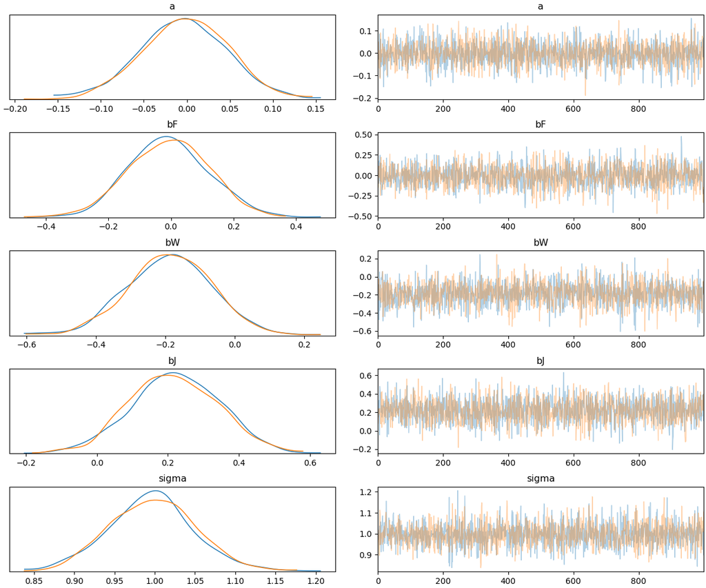

```python
_ = az.plot_trace(trace_2_1, var_names=['~mu'])
```

```python
pm.summary(trace_2_1, var_names=['~mu']).round(2)
```

|  | mean | sd | hpd_3% | hpd_97% | mcse_mean | mcse_sd | ess_mean | ess_sd | ess_bulk | ess_tail | r_hat |
| --- | --- | --- | --- | --- | --- | --- | --- | --- | --- | --- | --- |
| a | -0.00 | 0.05 | -0.09 | 0.10 | 0.0 | 0.0 | 2037.0 | 1034.0 | 2038.0 | 1453.0 | 1.0 |
| bF | -0.01 | 0.13 | -0.25 | 0.22 | 0.0 | 0.0 | 1859.0 | 1090.0 | 1868.0 | 1582.0 | 1.0 |
| bW | -0.19 | 0.12 | -0.42 | 0.03 | 0.0 | 0.0 | 2029.0 | 1588.0 | 2031.0 | 1498.0 | 1.0 |
| bJ | 0.22 | 0.12 | 0.00 | 0.46 | 0.0 | 0.0 | 2084.0 | 1955.0 | 2081.0 | 1686.0 | 1.0 |
| sigma | 1.00 | 0.05 | 0.90 | 1.09 | 0.0 | 0.0 | 2174.0 | 2170.0 | 2169.0 | 1515.0 | 1.0 |

There are $2^3$ different combinations. We can plot them all.

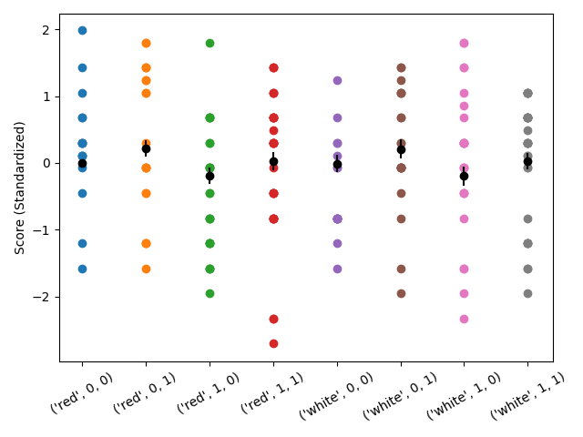

```python
fig, ax = plt.subplots(1,1)
fig.set_tight_layout(True)
# axes = axes.flatten()

a_ = trace_2_1['a']
bF_ = trace_2_1['bF']
bW_ = trace_2_1['bW']
bJ_ = trace_2_1['bJ']

mean = []
std = []
combinations = []

count=0
for f, lbl_f in enumerate(['red', 'white']):
    for w in [0,1]:
        for j in [0,1]:
            mu_ = a_ + bF_*f + bW_*w + bJ_*j
            mean.append(mu_.mean(axis=0))
            std.append(mu_.std(axis=0))
            combinations.append((lbl_f,w,j))
            fltr = (data['flight_idx'] == f) & (data['wine.amer'] == w) & (data['judge.amer'] == j)
            tmp = data[fltr]
            ax.scatter([count]*len(tmp), tmp['score_std_2'])

            count += 1


ax.errorbar(range(8), mean, yerr=std, ls='none', marker='o', c='k')
ax.set_xticks(range(8))
ax.set_xticklabels(combinations, rotation=30)
ax.set_ylabel('Score (Standardized)')
```

The labels are (flight, wine.amer, judge.amer)

## Index Variables

```python
with pm.Model() as model_2_2:

    bF = pm.Normal('bF',mu=0,sigma=0.5, shape=2)
    bW = pm.Normal('bW',mu=0,sigma=0.5, shape=2)
    bJ = pm.Normal('bJ',mu=0,sigma=0.5, shape=2)

    mu = pm.Deterministic('mu', bF[data['flight_idx']] + bW[data['wine.amer']] + bJ[data['judge.amer']])
    sigma = pm.Exponential('sigma', lam=1)

    score = pm.Normal('score', mu=mu, sigma=sigma, observed=data['score_std_2'])

    trace_2_2 = pm.sample(1000, tune=1000)
```

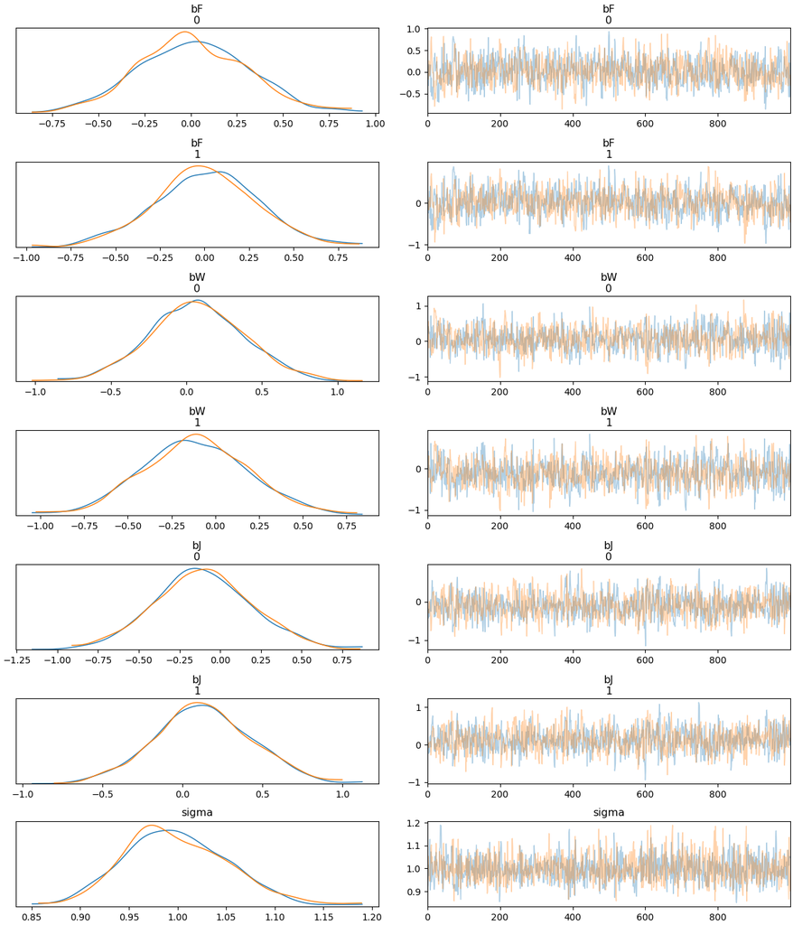

```python
_ = az.plot_trace(trace_2_2, var_names=['~mu'])
```

```python
pm.summary(trace_2_2, var_names=['~mu']).round(2)
```

|  | mean | sd | hpd_3% | hpd_97% | mcse_mean | mcse_sd | ess_mean | ess_sd | ess_bulk | ess_tail | r_hat |
| --- | --- | --- | --- | --- | --- | --- | --- | --- | --- | --- | --- |
| bF[0] | 0.02 | 0.30 | -0.52 | 0.59 | 0.01 | 0.01 | 851.0 | 851.0 | 852.0 | 970.0 | 1.0 |
| bF[1] | 0.01 | 0.29 | -0.56 | 0.54 | 0.01 | 0.01 | 784.0 | 757.0 | 784.0 | 886.0 | 1.0 |
| bW[0] | 0.07 | 0.31 | -0.55 | 0.62 | 0.01 | 0.01 | 903.0 | 639.0 | 903.0 | 864.0 | 1.0 |
| bW[1] | -0.11 | 0.31 | -0.68 | 0.47 | 0.01 | 0.01 | 904.0 | 707.0 | 904.0 | 892.0 | 1.0 |
| bJ[0] | -0.10 | 0.30 | -0.65 | 0.48 | 0.01 | 0.01 | 1004.0 | 916.0 | 1010.0 | 847.0 | 1.0 |
| bJ[1] | 0.13 | 0.30 | -0.44 | 0.71 | 0.01 | 0.01 | 1042.0 | 796.0 | 1042.0 | 887.0 | 1.0 |
| sigma | 1.00 | 0.06 | 0.90 | 1.10 | 0.00 | 0.00 | 1520.0 | 1496.0 | 1499.0 | 1339.0 | 1.0 |

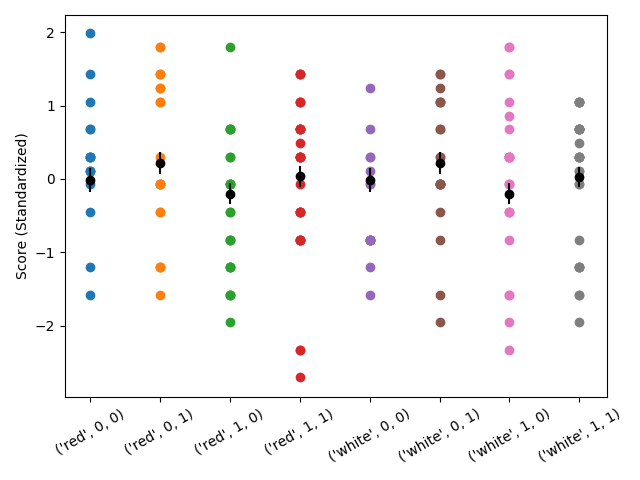

```python
fig, ax = plt.subplots(1,1)
fig.set_tight_layout(True)
# axes = axes.flatten()

bF_ = trace_2_2['bF']
bW_ = trace_2_2['bW']
bJ_ = trace_2_2['bJ']

mean = []
std = []
combinations = []

count=0
for f, lbl_f in enumerate(['red', 'white']):
    for w in [0,1]:
        for j in [0,1]:
            mu_ = bF_[:,f] + bW_[:,w] + bJ_[:,j]
            mean.append(mu_.mean(axis=0))
            std.append(mu_.std(axis=0))
            combinations.append((lbl_f,w,j))
            fltr = (data['flight_idx'] == f) & (data['wine.amer'] == w) & (data['judge.amer'] == j)
            tmp = data[fltr]
            ax.scatter([count]*len(tmp), tmp['score_std_2'])

            count += 1


ax.errorbar(range(8), mean, yerr=std, ls='none', marker='o', c='k')
ax.set_xticks(range(8))
ax.set_xticklabels(combinations, rotation=30)
ax.set_ylabel('Score (Standardized)')
```

The labels are (flight, wine.amer, judge.amer)

The plot is the same as for the indicator variables.

# 3

Adding two-way interactions:

- flight * wine.amer
- flight * judge.amer
- wine.amer * judge.amer

## Indicator Variable Model 1

Using the indicator variable F which is 0 for red wine and 1 for white wines

```python
F = theano.shared(data['flight_idx'].values)
W = theano.shared(data['wine.amer'].values)
J = theano.shared(data['judge.amer'].values)
```

```python
with pm.Model() as model_3_1:

    a = pm.Normal('a',mu=0,sigma=0.2)
    bF = pm.Normal('bF',mu=0,sigma=0.5)
    bJ = pm.Normal('bJ',mu=0,sigma=0.5)
    bW = pm.Normal('bW',mu=0,sigma=0.5)

    cJF = pm.Normal('cJF',mu=0,sigma=0.25)
    cWF = pm.Normal('cWF',mu=0,sigma=0.25)
    cWJ = pm.Normal('cWJ',mu=0,sigma=0.25)

    mu = pm.Deterministic('mu', a + bF*F + bW*W + bJ*J +cWF*F*W + cJF*F*J + cWJ*W*J)
    sigma = pm.Exponential('sigma', lam=1)

    score = pm.Normal('score', mu=mu, sigma=sigma, observed=data['score_std_2'])

    trace_3_1 = pm.sample(1000, tune=1000)
```

```
Auto-assigning NUTS sampler...
Initializing NUTS using jitter+adapt_diag...
Multiprocess sampling (2 chains in 2 jobs)
NUTS: [sigma, cWJ, cWF, cJF, bW, bJ, bF, a]
```

```python
pm.summary(trace_3_1, var_names=['~mu']).round(2)
```

|  | mean | sd | hpd_3% | hpd_97% | mcse_mean | mcse_sd | ess_mean | ess_sd | ess_bulk | ess_tail | r_hat |
| --- | --- | --- | --- | --- | --- | --- | --- | --- | --- | --- | --- |
| a | 0.01 | 0.13 | -0.25 | 0.24 | 0.00 | 0.0 | 1454.0 | 1164.0 | 1462.0 | 1368.0 | 1.0 |
| bF | -0.11 | 0.18 | -0.44 | 0.25 | 0.00 | 0.0 | 1266.0 | 1266.0 | 1280.0 | 1234.0 | 1.0 |
| bJ | 0.26 | 0.18 | -0.08 | 0.58 | 0.00 | 0.0 | 1297.0 | 1176.0 | 1298.0 | 1323.0 | 1.0 |
| bW | -0.25 | 0.18 | -0.57 | 0.10 | 0.00 | 0.0 | 1303.0 | 1233.0 | 1301.0 | 1382.0 | 1.0 |
| cJF | -0.00 | 0.19 | -0.36 | 0.35 | 0.01 | 0.0 | 1140.0 | 1140.0 | 1148.0 | 1171.0 | 1.0 |
| cWF | 0.21 | 0.19 | -0.15 | 0.54 | 0.00 | 0.0 | 1603.0 | 1496.0 | 1610.0 | 1310.0 | 1.0 |
| cWJ | -0.05 | 0.18 | -0.41 | 0.28 | 0.00 | 0.0 | 1397.0 | 1201.0 | 1401.0 | 1322.0 | 1.0 |
| sigma | 1.00 | 0.05 | 0.90 | 1.10 | 0.00 | 0.0 | 2274.0 | 2224.0 | 2359.0 | 1628.0 | 1.0 |

## Indicator Variable Model 2

Using the indicator variable R which is 1 for red wine and 0 for white wines, i.e. the orhtogonal choice to F.

```python
R = theano.shared((data['flight_idx'] == 0).values.astype('int64'))
```

```python
with pm.Model() as model_3_2:

    a = pm.Normal('a',mu=0,sigma=0.2)
    bR = pm.Normal('bR',mu=0,sigma=0.5)
    bJ = pm.Normal('bJ',mu=0,sigma=0.5)
    bW = pm.Normal('bW',mu=0,sigma=0.5)

    cJR = pm.Normal('cJR',mu=0,sigma=0.25)
    cWR = pm.Normal('cWR',mu=0,sigma=0.25)
    cWJ = pm.Normal('cWJ',mu=0,sigma=0.25)

    mu = pm.Deterministic('mu', a + bR*R + bW*W + bJ*J +cWR*R*W + cJR*R*J + cWJ*W*J)
    sigma = pm.Exponential('sigma', lam=1)

    score = pm.Normal('score', mu=mu, sigma=sigma, observed=data['score_std_2'])

    trace_3_2 = pm.sample(1000, tune=1000)
```

```
Auto-assigning NUTS sampler...
Initializing NUTS using jitter+adapt_diag...
Multiprocess sampling (2 chains in 2 jobs)
NUTS: [sigma, cWJ, cWR, cJR, bW, bJ, bR, a]
```

```python
pm.summary(trace_3_2, var_names=['~mu']).round(2)
```

|  | mean | sd | hpd_3% | hpd_97% | mcse_mean | mcse_sd | ess_mean | ess_sd | ess_bulk | ess_tail | r_hat |
| --- | --- | --- | --- | --- | --- | --- | --- | --- | --- | --- | --- |
| a | -0.05 | 0.13 | -0.28 | 0.22 | 0.0 | 0.0 | 1296.0 | 1130.0 | 1299.0 | 1373.0 | 1.0 |
| bR | 0.09 | 0.19 | -0.27 | 0.43 | 0.0 | 0.0 | 1554.0 | 1168.0 | 1552.0 | 1299.0 | 1.0 |
| bJ | 0.22 | 0.18 | -0.14 | 0.54 | 0.0 | 0.0 | 1294.0 | 1204.0 | 1288.0 | 1266.0 | 1.0 |
| bW | -0.08 | 0.17 | -0.38 | 0.23 | 0.0 | 0.0 | 1095.0 | 1095.0 | 1102.0 | 1321.0 | 1.0 |
| cJR | 0.04 | 0.19 | -0.30 | 0.40 | 0.0 | 0.0 | 1479.0 | 1159.0 | 1472.0 | 1399.0 | 1.0 |
| cWR | -0.22 | 0.18 | -0.57 | 0.10 | 0.0 | 0.0 | 1669.0 | 1509.0 | 1660.0 | 1459.0 | 1.0 |
| cWJ | -0.03 | 0.18 | -0.37 | 0.29 | 0.0 | 0.0 | 1122.0 | 1122.0 | 1115.0 | 1145.0 | 1.0 |
| sigma | 1.00 | 0.05 | 0.90 | 1.10 | 0.0 | 0.0 | 1876.0 | 1861.0 | 1842.0 | 1132.0 | 1.0 |

## Compare the two models

### Compare Parameters

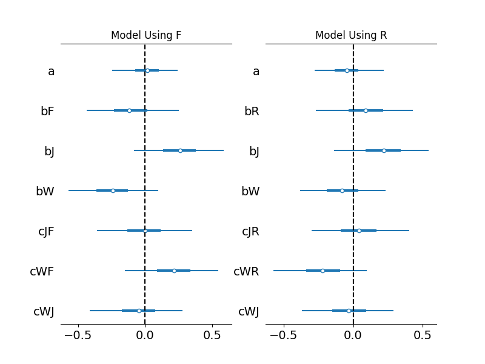

```python
fig, (ax1, ax2) = plt.subplots(1,2,figsize=(8,6))
az.plot_forest(trace_3_1, var_names=['~mu', '~sigma'], combined=True, figsize=(6,4), ax=ax1)
ax1.axvline(0,c='k', ls='--')
ax1.set_title('Model Using F')

az.plot_forest(trace_3_2, var_names=['~mu', '~sigma'], combined=True, figsize=(6,4), ax=ax2)
ax2.axvline(0,c='k', ls='--')
ax2.axvline(0,c='k', ls='--')
ax2.set_title('Model Using R')
```

### Compare Predictions

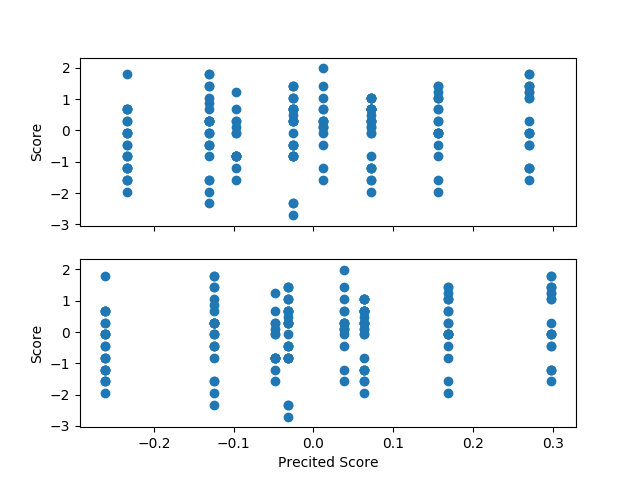

```python
fig, axes = plt.subplots(2,1,sharex=True,sharey=True)

axes[0].scatter(trace_3_1['mu'].mean(axis=0), data['score_std_2'])
axes[0].set_ylabel('Score')

axes[1].scatter(trace_3_2['mu'].mean(axis=0), data['score_std_2'])
axes[1].set_xlabel('Precited Score')
axes[1].set_ylabel('Score')
```

The predictions are different

```python
data.head()
```

|  | judge | flight | wine | score | wine.amer | judge.amer | score_std | judge_idx | wine_idx | score_std_2 | flight_idx |
| --- | --- | --- | --- | --- | --- | --- | --- | --- | --- | --- | --- |
| 0 | Jean-M Cardebat | white | A1 | 10.0 | 1 | 0 | 0.512821 | 0 | 0 | -1.576604 | 1 |
| 1 | Jean-M Cardebat | white | B1 | 13.0 | 1 | 0 | 0.666667 | 0 | 1 | -0.450458 | 1 |
| 2 | Jean-M Cardebat | white | C1 | 14.0 | 0 | 0 | 0.717949 | 0 | 2 | -0.075076 | 1 |
| 3 | Jean-M Cardebat | white | D1 | 15.0 | 0 | 0 | 0.769231 | 0 | 3 | 0.300306 | 1 |
| 4 | Jean-M Cardebat | white | E1 | 8.0 | 1 | 0 | 0.410256 | 0 | 4 | -2.327368 | 1 |

```python
ff = []
ww = []
jj = []
lbls = []
for j, lbl_j in enumerate(['F', 'A']):
    for f, lbl_f in zip([1,0], ['W', 'R']):
        for w, lbl_w in enumerate(['F', 'A']):
            ff.append(f)
            ww.append(w)
            jj.append(j)
            lbls.append(lbl_w+lbl_j+lbl_f)
rr = [1 if x==0 else 0 for x in ff]

print(lbls)
print(ww)
print(jj)
print(ff)
print(rr)
```

```
['FFW', 'AFW', 'FFR', 'AFR', 'FAW', 'AAW', 'FAR', 'AAR']
[0, 1, 0, 1, 0, 1, 0, 1]
[0, 0, 0, 0, 1, 1, 1, 1]
[1, 1, 0, 0, 1, 1, 0, 0]
[0, 0, 1, 1, 0, 0, 1, 1]
```

```python
# This is annoying, because it means that the traces are changed.
# I will need to undo it below.
F.set_value(ff)
R.set_value(rr)
W.set_value(ww)
J.set_value(jj)
```

```python
ppc_3_1 = pm.sample_posterior_predictive(trace_3_1, model=model_3_1, var_names=['score', 'mu'])
```

```python
ppc_3_2 = pm.sample_posterior_predictive(trace_3_2, model=model_3_2, var_names=['score', 'mu'])
```

```python
ppc_3_1
```

```
{'score': array([[ 1.59688368,  1.03987103, -0.56768737, ...,  1.80088614,
         -1.03157495,  0.02626909],
        [-1.01586365, -1.07342476, -0.78184016, ...,  0.52099599,
          0.84362668, -1.38440952],
        [-0.41158328, -0.37542451,  2.77396458, ..., -0.00740714,
          0.28782691,  0.32399145],
        ...,
        [-2.16549722, -0.59454046, -1.29681037, ..., -0.87177091,
          1.57695875,  0.34324001],
        [-1.69358721,  1.20245717, -0.65486799, ...,  0.13994936,
         -0.43340069,  0.90000056],
        [-0.99201317, -1.29675278,  0.24123222, ..., -0.60313699,
          1.85607993, -0.17769161]]),
 'mu': array([[-0.03441792, -0.51388747,  0.19865604, ..., -0.08835647,
          0.3545564 , -0.03987182],
        [-0.00448217, -0.16082254,  0.24849072, ...,  0.01429449,
          0.07274854, -0.14592812],
        [-0.19682945, -0.25163049,  0.17009394, ...,  0.14679985,
          0.22152923, -0.01783753],
        ...,
        [ 0.03350755, -0.34808102,  0.19898381, ...,  0.00311935,
          0.40577782,  0.01468646],
        [-0.39882512, -0.17951696, -0.2847285 , ..., -0.07176793,
          0.32373278,  0.07072341],
        [-0.41208608, -0.19526445, -0.24483083, ..., -0.24038032,
          0.19883072, -0.01707584]])}
```

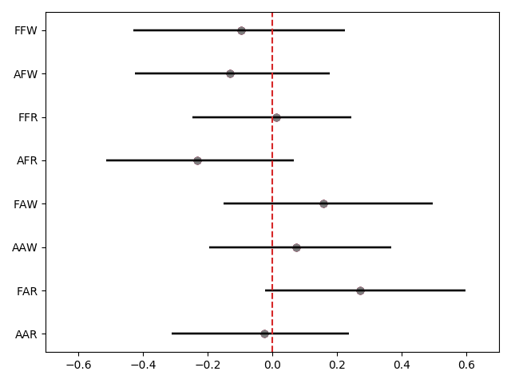

```
(-0.7, 0.7)
```

```python
means = ppc_3_1['mu'].mean(axis=0)
stds = ppc_3_1['mu'].std(axis=0)
hpds = az.hpd(ppc_3_1['mu'])

fig, ax = plt.subplots(1,1)
fig.set_tight_layout(True)

y = np.array(range(8))[::-1]
for i, lbl in enumerate(lbls):
    # ax.errorbar(means, y, xerr=hpds.T, ls='none', marker='o')
    ax.scatter(means, y)
    ax.hlines(y, hpds[:,0], hpds[:,1])

ax.set_yticks(range(8))
ax.set_yticklabels(lbls[::-1])
ax.axvline(x=0,ls='--', c='C3')
ax.set_xlim(-0.7,0.7)
```

FFW means French Wine, French Judge, White Wine, i,e, the order of the labels is Wine, Judge, Flight

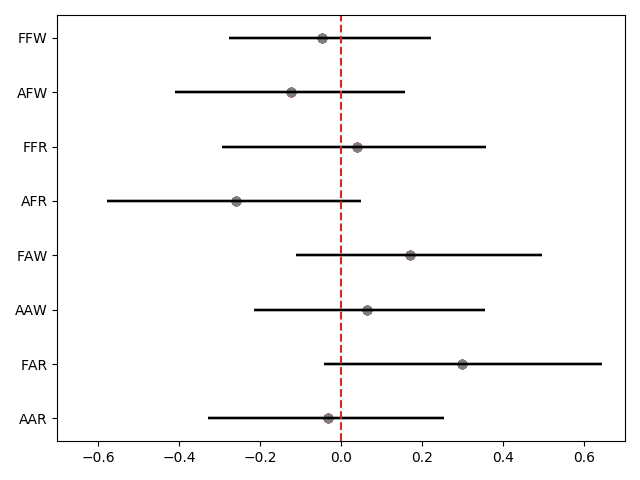

```
(-0.7, 0.7)
```

```python
means = ppc_3_2['mu'].mean(axis=0)
stds = ppc_3_2['mu'].std(axis=0)
hpds = az.hpd(ppc_3_2['mu'])

fig, ax = plt.subplots(1,1)
fig.set_tight_layout(True)

y = np.array(range(8))[::-1]
for i, lbl in enumerate(lbls):
    # ax.errorbar(means, y, xerr=hpds.T, ls='none', marker='o')
    ax.scatter(means, y)
    ax.hlines(y, hpds[:,0], hpds[:,1])

ax.set_yticks(range(8))
ax.set_yticklabels(lbls[::-1])
ax.axvline(x=0,ls='--', c='C3')
ax.set_xlim(-0.7,0.7)
```

FFW means French Wine, French Judge, White Wine

The choice of how to encode the wine flight makes a difference for the parameter values. It also makes a small difference for the predictions.

## Why Does the Choice of How to Encode the Flight Matter?

In principle one would expect that whether we encode the flight with 'red'=1 or 'white'=1 does not matter. Remeber that in the code above I used the varable F to encode 'white'=1 and the variable R to encode 'red'=1. Changing the encoding from F to R is just a linear transformation since R = 1 - F.

It is not surprising that such a linear transformation changes the parameter values, but it is perhaps surprising that it changes the predictions. I think the change in predictions occurs because the linear transformation changes how the model assigns uncertainties to the individual observations. The terms that change because of the linear transformations are: $$ \mathrm{score} = \mathrm{b_F} F + \mathrm{c_{JF}} F J + \mathrm{c_{WF}} F W + \mathrm{Rest} $$

[output not shown]

If instead we use R as a variable, but otherwise formulate the model in the same manner (the coefficients would be different so I add a tilde) we would get $$ \mathrm{score} = \mathrm{\tilde{a}} + \mathrm{\tilde{b}_W} $$

So the model using R as a variable assigns less uncertainty to this particular combination than the model using F.

## Index Variable Model

If we include a 3-term interaction there is a total of 8 interaction parmeters that we can encode as a 2x2x2 array.

```python
# redefine the variables, because I changed them above
F = theano.shared(data['flight_idx'].values)
W = theano.shared(data['wine.amer'].values)
J = theano.shared(data['judge.amer'].values)
R = theano.shared((data['flight_idx'] == 0).values.astype('int64'))
```

```python
with pm.Model() as model_3_3:

    a = pm.Normal('a', mu=0,sigma=0.5,shape=(2,2,2))
    mu = pm.Deterministic('mu', a[F,W,J])
    sigma = pm.Exponential('sigma', lam=1)

    score = pm.Normal('score', mu=mu,sigma=sigma, observed=data['score_std_2'])

    trace_3_3 = pm.sample(1000, tune=1000)
```

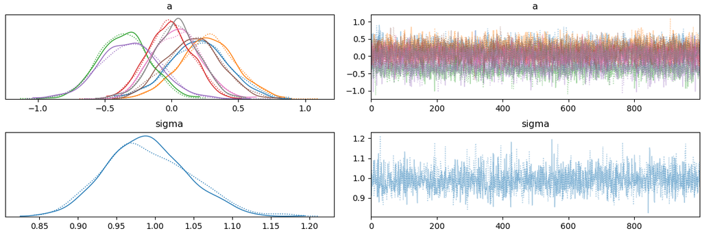

```
array([[<matplotlib.axes._subplots.AxesSubplot object at 0x7ff8dcb4b850>,
      dtype=object)
```

```python
az.plot_trace(trace_3_3, var_names=['~mu'], compact=True)
```

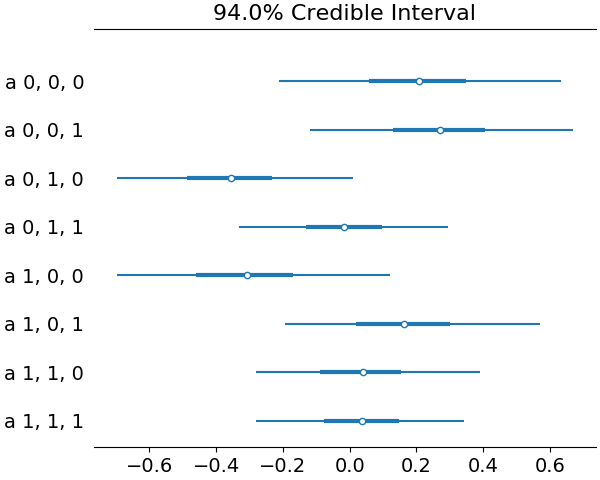

```
array([<matplotlib.axes._subplots.AxesSubplot object at 0x7ff8d86e7a10>],
      dtype=object)
```

```python
az.plot_forest(trace_3_3, var_names=['~mu', '~sigma'],combined=True)
```

### Plot Predictions

```python
ff = []
ww = []
jj = []
lbls = []
for j, lbl_j in enumerate(['F', 'A']):
    for f, lbl_f in zip([1,0], ['W', 'R']):
        for w, lbl_w in enumerate(['F', 'A']):
            ff.append(f)
            ww.append(w)
            jj.append(j)
            lbls.append(lbl_w+lbl_j+lbl_f)
rr = [1 if x==0 else 0 for x in ff]

print(lbls)
print(ww)
print(jj)
print(ff)
print(rr)
```

```
['FFW', 'AFW', 'FFR', 'AFR', 'FAW', 'AAW', 'FAR', 'AAR']
[0, 1, 0, 1, 0, 1, 0, 1]
[0, 0, 0, 0, 1, 1, 1, 1]
[1, 1, 0, 0, 1, 1, 0, 0]
[0, 0, 1, 1, 0, 0, 1, 1]
```

```python
# This is annoying, because it means that the traces are changed.
# I will need to undo it below.
F.set_value(ff)
R.set_value(rr)
W.set_value(ww)
J.set_value(jj)
```

```python
ppc_3_3 = pm.sample_posterior_predictive(trace_3_3, model=model_3_3, var_names=['score', 'mu'])
```

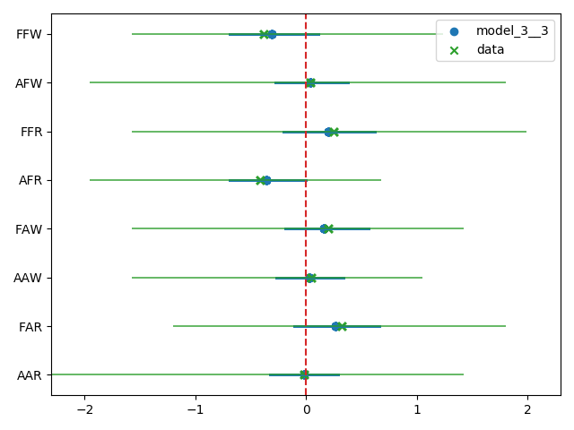

```python
means = ppc_3_3['mu'].mean(axis=0)
stds = ppc_3_3['mu'].std(axis=0)
hpds = az.hpd(ppc_3_3['mu'])

fig, ax = plt.subplots(1,1)
fig.set_tight_layout(True)

y = np.array(range(8))[::-1]
for i, lbl in enumerate(lbls):
    # ax.errorbar(means, y, xerr=hpds.T, ls='none', marker='o')
    if i == 0:
        ax.scatter(means, y, label='model_3__3', color='C0')
    else:
        ax.scatter(means, y, color='C0')
    ax.hlines(y, hpds[:,0], hpds[:,1], color='C0', lw=2)

# plot the means of the data
means_d = []
hpds_d = np.zeros((8,2))

count = 0
for i_f, i_w, i_j in zip(ff,ww,jj):
    fltr = (data['flight_idx'] == i_f) & (data['wine.amer'] == i_w) & (data['judge.amer'] == i_j)
    means_d.append(data['score_std_2'][fltr].mean())
    hpds_d[count,:] = az.hpd(data['score_std_2'][fltr])
    count += 1

for i, lbl in enumerate(lbls):
    # ax.errorbar(means, y, xerr=hpds.T, ls='none', marker='o')
    if i ==0:
        ax.scatter(means_d, y, c='C2', marker='x', label='data')
    else:
        ax.scatter(means_d, y, c='C2', marker='x')
    ax.hlines(y, hpds_d[:,0], hpds_d[:,1], color='C2', lw=0.2)


ax.set_yticks(range(8))
ax.set_yticklabels(lbls[::-1])
ax.axvline(x=0,ls='--', c='C3')
ax.set_xlim(-2.3,2.3)
ax.legend(loc=0)
```

The model means are very close to the data. I would have expected them to be the same, because there are 8 parameters and only 8 means to caclulate.

Note that the credible interval for the data is much larger, because when calculating the credible interval for the model I am not using sigma.

# Convert to HTML

```python
os.system('jupyter nbconvert --to html week05.ipynb')
```

```
0
```